# Tower of Hanoi

## Tower of Hanoi

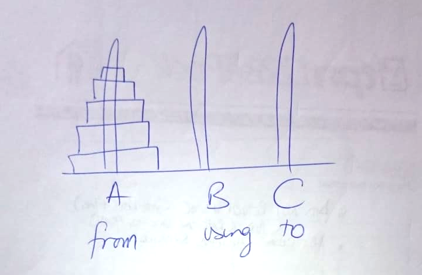

Problem: We have 5 disks on Tower A, and need to move it over Tower C,

Rules:

1. One Disk at time
2. No larger disk should be over a smaller disk
3. Can use Tower B, as axillary tower

A = from (this is always the source) (1st parameter)

B = using (this is the intermediary) (2nd parameter)

C = to (this is always the destination) (3rd parameter)

So A is the source (move from), and C is the destination (move to). Those are the parameter positions. And B is just intermediary position.S

This problem can use solved using recursion.

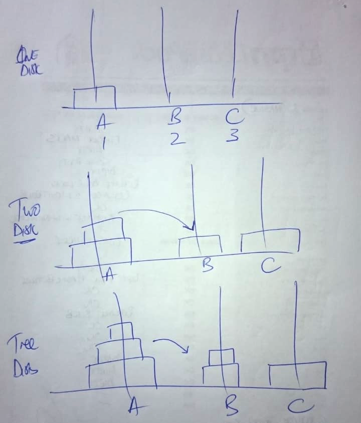

Lets break up problem for:

1. One Disk (set)
2. Two Disk (set)
3. Three Disk (set)

**One Disk (set)**

TOH (1, A, B, C)

Move Disk from A to C using B (this move is the destination)

Whenever we have the above statement, its final move, the rest is taken as recursive function

A = Source C = Destination B = using (not really, but use it)

**Two Disk (set)**

TOH (2, A, B, C)

1. Move Disk from A to B, not to C

But this move is NOT the destination. So moving there is temporary or we can say that moving there is recursively.

So,

How we we read above? A is source went to destination, which must be in place where C (3rd parameter). So that leaves C, to take the place of the 2nd parameter

1. Move the larger disk from A to C

Is this the final destination? Yes, its same step, where we have a single disk, so we write:

Move Disk from A to C, using B

But this is not

Next Move disk form B to C

Is this the final destination? No. This is also a recursive step

1. TOH (1, B, A, C)

How do we read this? B is source and needs to go to destination, so We put dowb C, and A is the intermediary.

**Three Disk (set)**

This is a combination of moving 1 disk and 2 disks, ie. the functions above gets reused.

TOH (3, A, B, C)

1. TOH (2, A, C, B)
2. Move Disk from A to C, using B
3. TOH (2, B, A, C)

Step 1, we perform what we did when we had 2 disks.

It seem that we moving 2 disks, but we simple reusing the recursive function of it.

Step 2, this is single move

From the above we can generate move for n number of disks

TOH (n, A, B, C)

1. TOH (n-1, A, C, B)
2. Move Disk from A to C, using B
3. TOH (n-1, B, A, C)

```python
#include <iostream>
#include <climits>
#include <math.h>
using namespace std;
```

## Using recursion

Lets trace it .

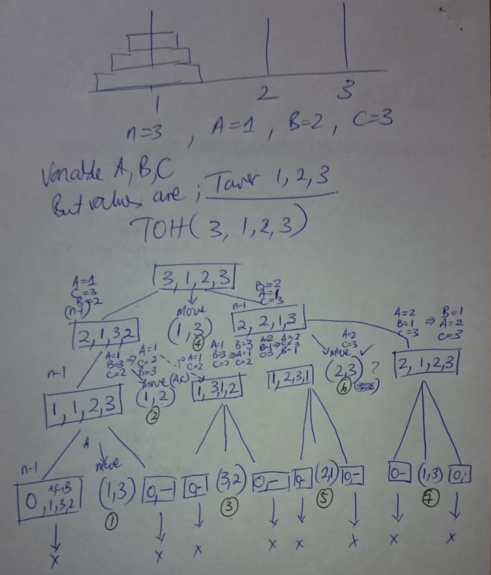

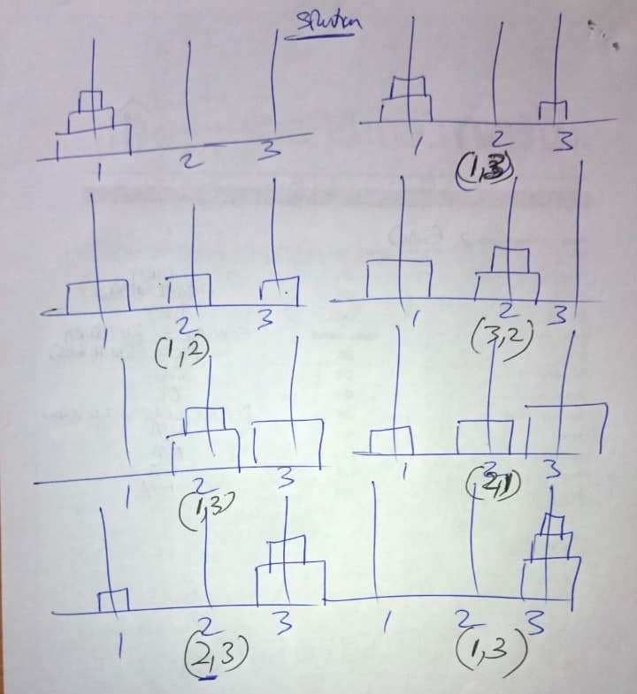

In order transversal..

How much time

n= 3, making 15 calls n=2, making 7 calls

Which is:

$$1+2+ {2^2} + {2^3} = {2^4} - 1 = 15 $$

Time taken is $$1+2+ {2^2} + {2^3}+...+ {2^n}= {2^{n+1}} - 1 $$

$$\text O(2^n) $$$$\text{Exponential} $$

Very time consuming..

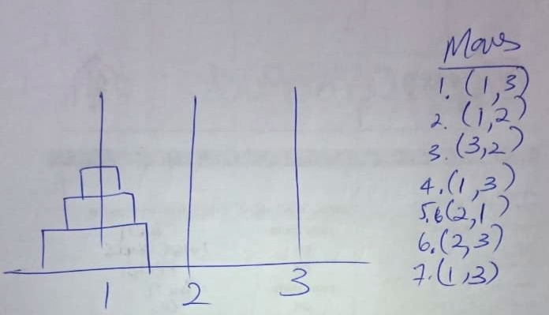

```python
void TOH(int n, int A, int B, int C);
```

```python
void TOH(int n,int A, int B, int C){
    if (n> 0)  {
        TOH(n-1, A, C, B);
        cout<<"("<<A<<","<<C<<")"<<endl;
        TOH(n-1, B, A, C);
    }
}
```

```python
int n=3, A=1, B=2, C=3;

TOH(n,A, B, C);
```

```
(1,3)
(1,2)
(3,2)
(1,3)
(2,1)
(2,3)
(1,3)
```